# Composition Analysis of the VD17 dated 2025-09-26

# Overall summary

314,874 records and 35,197,973 attribute values in total. Constituent files:

- data/vd17/vd17.parquet (121MB)

## Temporal overview

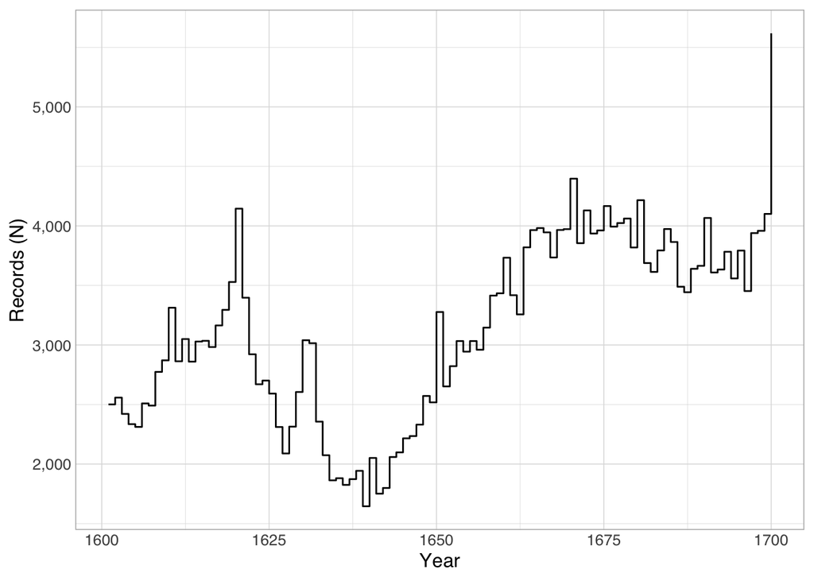

48 records do not have easily parseable dates between the years 1601 and 1700.

## Language overview

| [] | Records (N) | Proportion (%) |
| --- | --- | --- |
| lat (Latin) | 173047 | 0.516811215042588 |
| ger (German) | 149597 | 0.446776929601357 |
| fre (French) | 3596 | 0.0107395859465529 |
| grc (Greek, Ancient (to 1453)) | 2721 | 0.00812636634053686 |
| NA | 1520 | 0.0045395357727365 |
| ita (Italian) | 1302 | 0.00388847077375193 |
| heb (Hebrew) | 1245 | 0.00371823818227431 |
| nds (Low German; Low Saxon; German, Low; Saxon, Low) | 318 | 0.000949718668243558 |
| dut (Dutch; Flemish) | 234 | 0.000698849586066014 |
| gre (Greek, Modern (1453-)) | 153 | 0.00045694011396624 |

[output cut: 54 more lines]

# Field code usage overview

In total, 182 distinct fields are used.

Legend for the table below:

- `records`: how many records have at least one of this field
- `r_p`: the above as a percentage of all records
- `n`: the total number of appearances of this field
- `vals_per_rec`: calculated from the above, the mean number of appearances of this field per record
- `recs_with_mult_vals`: the number of records that have more than one repetition of this field

| field_code | field_description | records | r_p | n | vals_per_rec | recs_with_mult_vals |
| --- | --- | --- | --- | --- | --- | --- |
| <a name="000e">000e</a> | NA | 9 | 2.8582861716115e-05 | 18 | 2 | 9 |
| <a name="000i">000i</a> | NA | 139 | 0.000441446419837776 | 278 | 2 | 139 |
| <a name="001@" href="https://swbtools.bsz-bw.de/cgi-bin/k10plushelp.pl?cmd=kat&val=0000">001@</a> | ILN-bits, supplier code a.o. | 314795 | 0.999749105991603 | 314795 | 1 | 0 |
| <a name="001A" href="https://swbtools.bsz-bw.de/cgi-bin/k10plushelp.pl?cmd=kat&val=0200">001A</a> | Kennung und Datum der Ersterfassung | 314874 | 1 | 314874 | 1 | 0 |
| <a name="001B" href="https://swbtools.bsz-bw.de/cgi-bin/k10plushelp.pl?cmd=kat&val=0210">001B</a> | Kennung und Datum der letzten Änderung | 314874 | 1 | 629748 | 2 | 314874 |
| <a name="001D" href="https://swbtools.bsz-bw.de/cgi-bin/k10plushelp.pl?cmd=kat&val=0230">001D</a> | Kennung und Datum der Statusänderung | 314874 | 1 | 314874 | 1 | 0 |
| <a name="001U" href="https://swbtools.bsz-bw.de/cgi-bin/k10plushelp.pl?cmd=kat&val=000K">001U</a> | Characterset | 314874 | 1 | 314874 | 1 | 0 |
| <a name="001X" href="https://swbtools.bsz-bw.de/cgi-bin/k10plushelp.pl?cmd=kat&val=000A">001X</a> | Owner main record | 314874 | 1 | 314874 | 1 | 0 |
| <a name="002@" href="https://swbtools.bsz-bw.de/cgi-bin/k10plushelp.pl?cmd=kat&val=0500">002@</a> | Bibliografische Gattung und Status | 314874 | 1 | 314874 | 1 | 0 |
| <a name="002C" href="https://swbtools.bsz-bw.de/cgi-bin/k10plushelp.pl?cmd=kat&val=0501">002C</a> | Inhaltstyp | 17905 | 0.0568640154474488 | 36099 | 2.01614074280927 | 17904 |

[output cut: 172 more lines]

# Field code usage overview by subfield

In total, 777 distinct field+subfield combinations are used.

Legend for the table below:

- `records`: how many records have at least one of this field+subfield
- `r_p`: the above as a percentage of all records
- `dist_vals`: the number of different values appearing in this field+subfield
- `e_vals`: at most seven random sample values of this field+subfield
- `n`: the total number of appearances of this field+subfield
- `vals_per_rec`: calculated from the above, the mean number of appearances of this field+subfield per record
- `recs_with_mult_vals`: the number of records that have more than one repetition of this field+subfield

| subfield_code | subfield_description | records | r_p | dist_vals | e_vals | n | vals_per_rec | recs_with_mult_vals |
| --- | --- | --- | --- | --- | --- | --- | --- | --- |
| 000e: NA |  |  |  |  |  |  |  |  |
| 000e$. | NA | 9 | 0% | 9 | 25,14 (1)\|7 (1)\|22 (1)\|14 (1)\|4 (1)\|5 (1)\|24 (1) | 9 | 1 | 0 |
| 000e$x | NA | 9 | 0% | 1 | 00 (9) | 9 | 1 | 0 |
| 000i: NA |  |  |  |  |  |  |  |  |
| 000i$d | NA | 139 | 0.04% | 14 | . 4 (3)\|. 2 (12)\|. 7 (2)\|. 5 (5)\|. 14 (1)\|.46 (1)\|. 1 (15) | 139 | 1 | 0 |
| 000i$x | NA | 139 | 0.04% | 1 | 00 (139) | 139 | 1 | 0 |
| [001@: ILN-bits, supplier code a.o.](https://swbtools.bsz-bw.de/cgi-bin/k10plushelp.pl?cmd=kat&val=0000) |  |  |  |  |  |  |  |  |
| 001@$0 | ILN-bits, userbits | 314,795 | 99.97% | 26,216 | 50,278,2010 (5)\|50,61,2018,4012 (2)\|62,2006,4012 (26)\|11,61,65,2006,2010,4012,4113 (1)\|11,40,2006,4126 (1)\|40,61,65,4396 (1)\|11,40,50,61,2006,4002,4012 (1) | 314,795 | 1 | 0 |
| [001A: Kennung und Datum der Ersterfassung](https://swbtools.bsz-bw.de/cgi-bin/k10plushelp.pl?cmd=kat&val=0200) |  |  |  |  |  |  |  |  |
| 001A$0 | Kennung und Datum der Ersterfassung | 314,874 | 100% | 26,464 | 4620:04-11-10 (1)\|0003:03-07-07 (11)\|0009:22-02-18 (5)\|0023:06-06-14 (3)\|0023:08-01-07 (6)\|0028:19-12-22 (1)\|0014:18-10-06 (1) | 314,874 | 1 | 0 |
| [001B: Kennung und Datum der letzten Änderung](https://swbtools.bsz-bw.de/cgi-bin/k10plushelp.pl?cmd=kat&val=0210) |  |  |  |  |  |  |  |  |
| 001B$0 | Kennung und Datum | 314,874 | 100% | 9,240 | HDUB:20-10-23 (5)\|0001:20-04-23 (1)\|0547:01-07-22 (8)\|0023:07-09-22 (6)\|L1BV:20-09-21 (1)\|0012:17-10-22 (1)\|0009:11-07-23 (4) | 314,874 | 1 | 0 |
| 001B$t | Uhrzeit | 314,874 | 100% | 49,886 | 14:19:12.000 (9)\|08:24:12.000 (2)\|22:22:54.000 (6)\|13:08:57.000 (3)\|09:47:48.000 (4)\|10:16:51.000 (6)\|18:52:49.000 (9) | 314,874 | 1 | 0 |
| [001D: Kennung und Datum der Statusänderung](https://swbtools.bsz-bw.de/cgi-bin/k10plushelp.pl?cmd=kat&val=0230) |  |  |  |  |  |  |  |  |
| 001D$0 | Kennung und Datum | 314,874 | 100% | 4,467 | 0824:27-09-19 (1)\|0115:07-04-22 (5)\|0001:15-04-25 (4)\|DDSU:22-05-24 (2)\|0009:03-07-23 (5)\|L1UB:10-03-21 (6)\|0023:25-09-24 (1) | 314,874 | 1 | 0 |
| [001U: Characterset](https://swbtools.bsz-bw.de/cgi-bin/k10plushelp.pl?cmd=kat&val=000K) |  |  |  |  |  |  |  |  |
| 001U$0 | Unicode-Kennzeichen | 314,874 | 100% | 1 | utf8 (314874) | 314,874 | 1 | 0 |
| [001X: Owner main record](https://swbtools.bsz-bw.de/cgi-bin/k10plushelp.pl?cmd=kat&val=000A) |  |  |  |  |  |  |  |  |
| 001X$0 | Owner | 314,874 | 100% | 1 | 0 (314874) | 314,874 | 1 | 0 |
| [002@: Bibliografische Gattung und Status](https://swbtools.bsz-bw.de/cgi-bin/k10plushelp.pl?cmd=kat&val=0500) |  |  |  |  |  |  |  |  |
| 002@$0 | Bibliografische Gattung und Status | 314,874 | 100% | 8 | AFu (280)\|Afu (18391)\|Aaus (15)\|AauZ (3)\|Aav (2)\|Acu (5109)\|Aay (21) | 314,874 | 1 | 0 |
| [002C: Inhaltstyp](https://swbtools.bsz-bw.de/cgi-bin/k10plushelp.pl?cmd=kat&val=0501) |  |  |  |  |  |  |  |  |
| 002C$2 | Quelle des Typs | 52 | 0.02% | 1 | rdacontent (52) | 52 | 1 | 0 |
| 002C$a | Inhaltstyp in ausgeschriebener Form | 17,905 | 5.69% | 5 | unbewegtes Bild (108)\|Noten (19)\|Text (17893)\|kartografisches Bild (3)\|txt (1) | 18,024 | 1.01 | 117 |
| 002C$b | Inhaltstyp in codierter Form | 17,904 | 5.69% | 4 | ntm (19)\|txt (17893)\|sti (108)\|cri (3) | 18,023 | 1.01 | 117 |
| [002D: Medientyp](https://swbtools.bsz-bw.de/cgi-bin/k10plushelp.pl?cmd=kat&val=0502) |  |  |  |  |  |  |  |  |
| 002D$2 | Quelle des Typs | 52 | 0.02% | 1 | rdamedia (52) | 52 | 1 | 0 |
| 002D$a | Medientyp in ausgeschriebener Form | 17,906 | 5.69% | 2 | n (1)\|ohne Hilfsmittel zu benutzen (17908) | 17,909 | 1 | 3 |
| 002D$b | Medientyp in codierter Form | 17,905 | 5.69% | 1 | n (17908) | 17,908 | 1 | 3 |
| [002E: Datenträgertyp](https://swbtools.bsz-bw.de/cgi-bin/k10plushelp.pl?cmd=kat&val=0503) |  |  |  |  |  |  |  |  |

[output cut: 929 more lines]